# Bootstrapping

Author

Neil Lund

# Quick refresher on the point of bootstrapping

(I felt like I might have glossed over some important information when we talked about this in class last week, so this is just a quick write-up on the intuition behind bootstrapping and why it might be useful, along with some R code to illustrate how it works and how we can verify that it produces good confidence intervals. Its not required course material, but it might be helpful if you understood how to answer the homework but weren’t quite sure why you should care)

The Central Limit Theorem says that, in repeated sampling, sample means drawn from a fixed population will converge towards a normal distribution centered around the true population mean. This is true even if the population we’re drawing from is not normally distributed.

Sample means are so well-behaved that we never really need to bother with empirically validating that they’re going to be normally distributed like this. Its an assumption we can just make any time we’re working with sample averages of a sufficient size. We may never know the “true” population value for a given statistic, but we can still tell you how likely you are to get a sample mean that’s off the mark by 2 standard errors because we know how sample means will fall around the population mean:

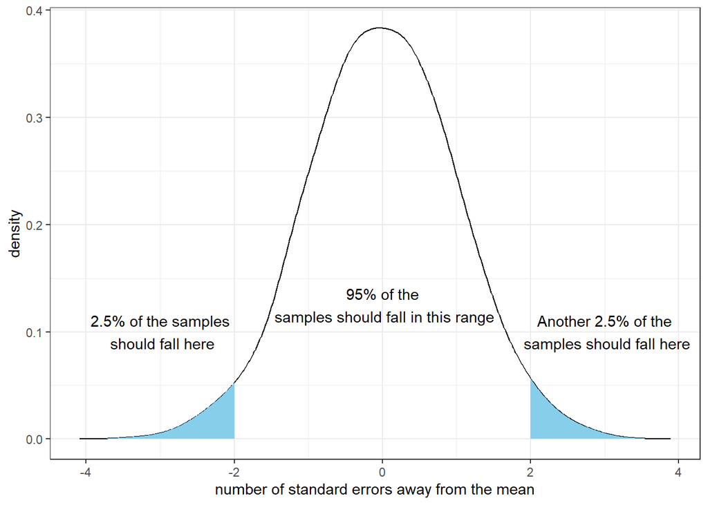

So when we calculate a confidence interval for a mean, we’re applying this knowledge to say, in essence, “we’re pretty sure that the actual population average falls somewhere in this range because of what we know about how sample averages are distributed”.

**Pedantry point**

Technically, a X% confidence interval means that X% of the confidence intervals generated this way would contain the population parameter. So “if we did this survey 1000 times and calculated a 95% confidence interval every time, then 950 out of 1000 of those confidence intervals would contain the true population mean”. But no one actually talks like this, so I think its often more helpful to just say its the range we’re pretty certain contains the true value.

The reason we use a bootstrap is that **sometimes we want to create confidence intervals in places where the Central Limit Theorem doesn’t apply**. For many useful summary statistics (like a median or an odds ratio), there’s no analog to the Central Limit Theorem. We may have no notion of how they will behave in repeated sampling, if they even behave consistently at all. So bootstrapping allows us to estimate confidence intervals for these statistics without requiring any assumptions about how they’re distributed. This is what people mean when they describe the bootstrap as a “non-parametric” method for estimating a confidence interval: its completely agnostic about the sampling distribution of our statistic.

# Bootstrapping

In general, we’ll perform the bootstrap like this:

1. Sample (with replacement) from our original data until we get a new sample of the same size.
2. Calculate the statistic of interest for this new sample.
3. Rinse-and-repeat until we’ve got hundreds or thousands of estimates

Since we’re sampling from our own sample, each of these new simulated samples will end up looking very similar to the original, but they won’t be exact copies because we’re sampling with replacement. So some observations will be missing and others will be duplicated. This random variability will (hopefully) simulate the random variability that we would actually see if we actually drew new samples from the population over and over again, and we can use it to infer the sampling distribution for our statistic of interest.

We can do all of this in R using some loops and functions. We’ll start by generating some random data that we can work with. The code below draws 5000 observations from a beta distribution with a heavy rightward skew.

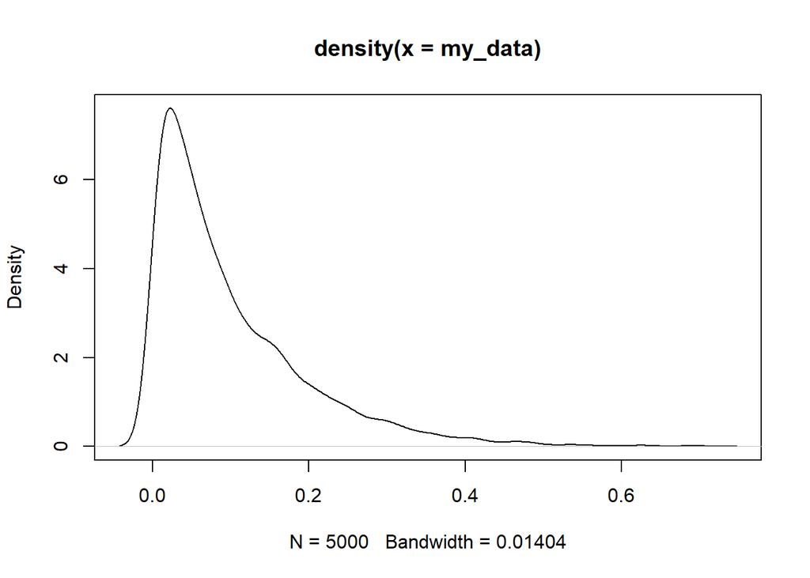

```r
set.seed(100) # set the random number seed (ensures we can replicate our results)
my_data<-rbeta(5000,1,100)*10 # draw some very skewed data

plot(density(my_data))
```

Remember that our bootstrapping process worked by repeatedly resampling with replacement from the original sample, calculating the median on these new samples, and then calculating the 2.5th and 97.5th percentiles to create a 95% confidence interval around our estimate.

So, here’s our loop to create 1000 bootstrapped sample medians:

```r
my_medians <- c()
for(i in 1:1000){
  # sample with replacement from the data:
  new_sample<-sample(my_data, size=length(my_data), replace=T)
  # calculate the median of the new sample
  new_median<-median(new_sample)

  # now store the result
  my_medians<-c(my_medians, new_median)

}
```

Now we should have a vector with 1000 medians drawn from 1000 simulated replications of our original sample. All we need for our 95% confidence interval is to find the range where 95% of the data occurs. In other words: we’ll take the range from the 2.5th percentile to the 97.5th percentile. We can also use the 50th percentile as our point estimate:

```r
quantile(my_medians, c(0.025, .5, .975))
```

```
      2.5%        50%      97.5%
0.06533366 0.06778661 0.07080150
```

And this value represents the 95% confidence interval for our estimated median.

Something to note here: the bootstrapped medians `still` aren’t really normal (and they never will be). This is fine though, because the bootstrap doesn’t rely on assumptions of normality.

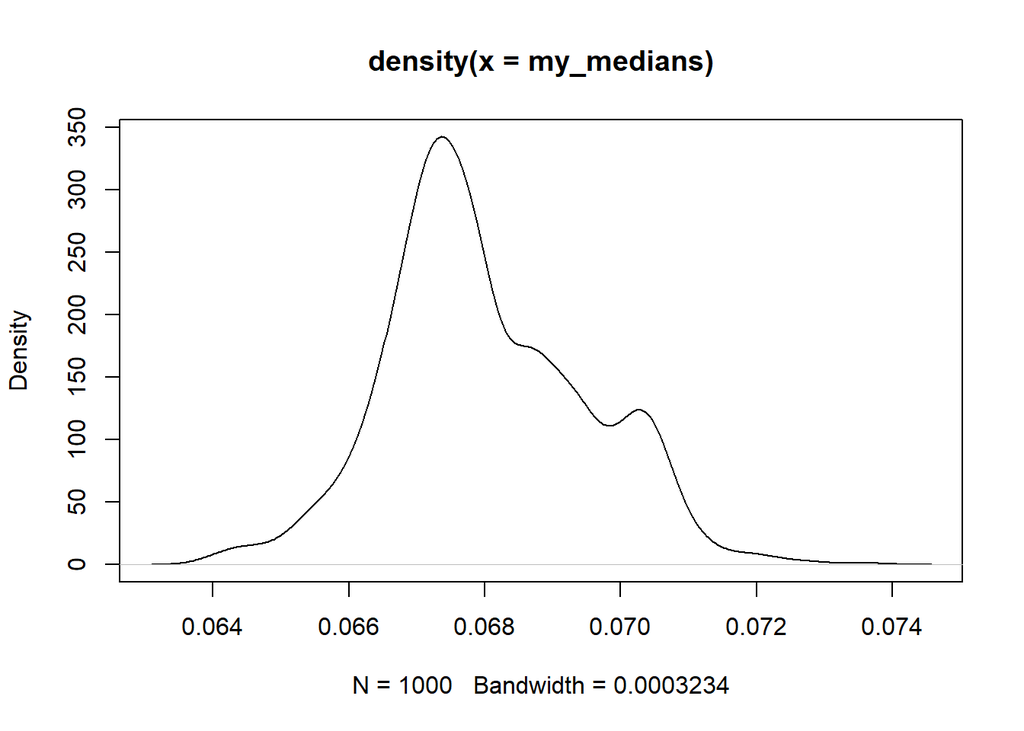

```r
plot(density(my_medians))
```

# Putting it in a function

We’ve already got our loop, now we want to generalize it and then wrap the code up in a function that we can re-use. So take a look at the code and ask yourself: what parts of this might change the next time I need to do this? And what parts will always be more-or-less the same?

The parts that need to change should become function arguments. The parts that will stay the same should…stay the same.

For starters, I’m assuming my data will change. So I’m going to swap `my_data` with something more generic like `x`. Moreover, there may be cases where I want to change the number of bootstrap replicates. So I’m going to replace the `for i in 1:1000` with `for i in 1:n`, and then I can control the number of iterations.

```r
bootMedian <- function(x, n) {
  my_medians <- c()
  for (i in 1:n) {
    # sample with replacement from X:
    new_sample <- sample(x, size = length(x), replace = T)
    # calculate the median of the new sample
    new_median <- median(new_sample)

    # now store the result
    my_medians <- c(my_medians, new_median)

  }
  result<-quantile(my_medians, c(0.025, .5, .975))

  return(result)
}
```

Now, with our new function, we can run the same process for new data, and we can adjust the number of iterations as needed. (for bootstrapping, more is always better, but things start to get slow after a while)

```r
bootMedian(x=my_data, n=3000)
```

```
      2.5%        50%      97.5%
0.06524476 0.06778269 0.07094898
```

# Simulating the results

Recall that claim we’re making with our bootstrapped 95% confidence intervals is that “in repeated sampling, approximately 95% of the confidence intervals created this way would contain the true population parameter.” In the real world, we don’t have an efficient way to test this empirically: if we knew the population parameter, we wouldn’t be bothering to take a sample in the first place! But we can simulate a “population” with known parameters and then verify that our procedure works by simulating the process of repeatedely drawing samples from it.

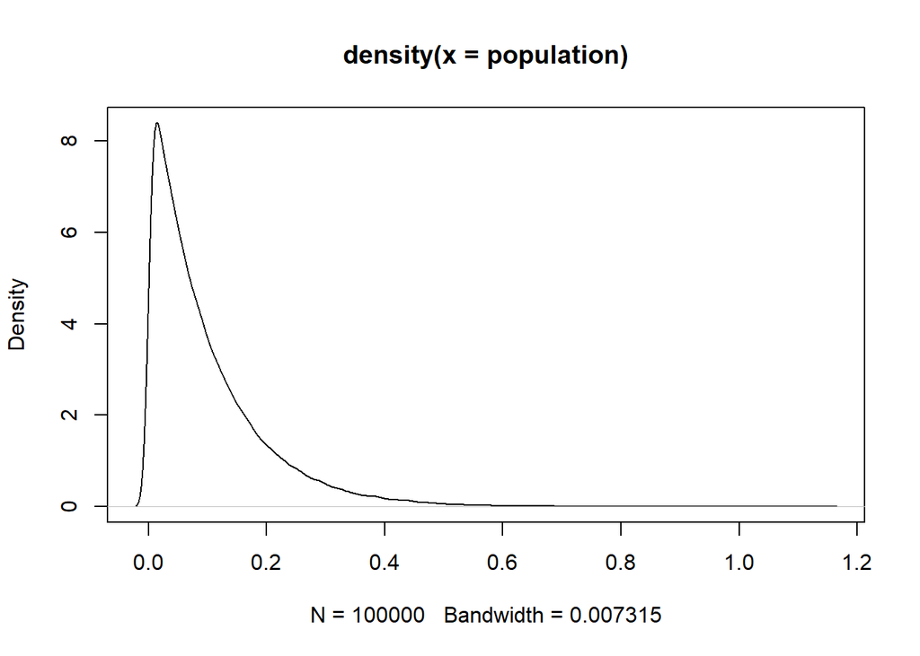

```r
set.seed(999)
population<-rbeta(100000,1,100)*10


plot(density(population))
```

This value represents our “true” population median:

```r
# imagine this is our "true" population median:
population_median<-median(population)
print(population_median)
```

```
[1] 0.06913232
```

```r
multiple_replications <-
  # The replicate function just repeats a process n times. So its a short way to
  # write a loop
  replicate(1000, expr = {
    # sample 300 observations from the population without replacement
    sampled_data <- sample(population, size = 300, replace=FALSE)

    bootMedian(sampled_data, n = 1000)


  })
```

If our process works, then 95% of the confidence intervals should contain the true population statistic. In the plot below, the red lines represent cases where the 95% confidence interval didn’t contain the population parameter.

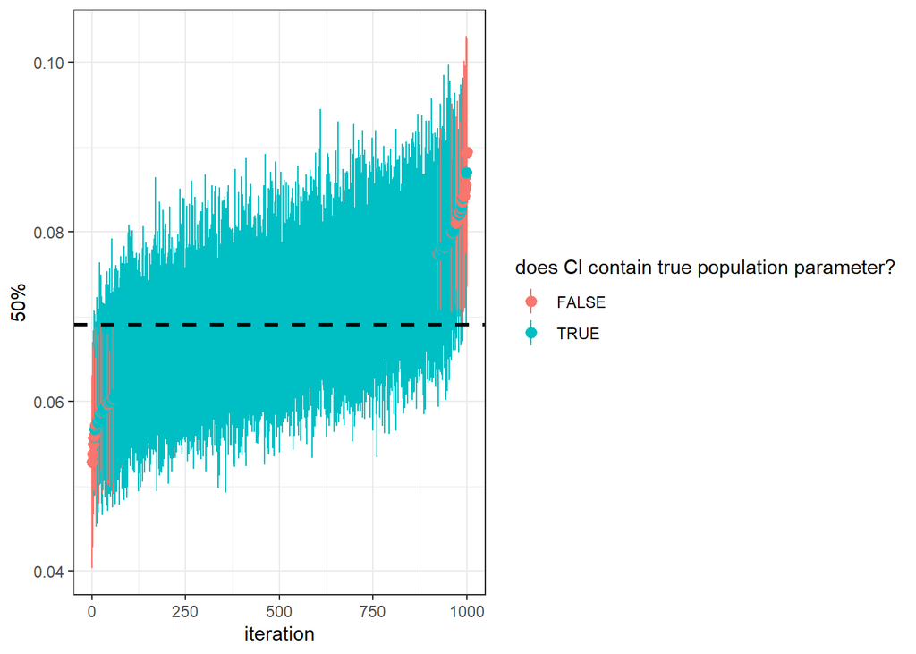

```r
df<-multiple_replications|>
  t()|>
  as_tibble()|>
  arrange(`50%`)|> # sort from highest to lowest
  mutate(iteration = seq(n()), # add an indicator for each run of the bootstrap

         # check whether the CI contains the population parameter:
         `does CI contain true population parameter?`  =
           population_median>`2.5%` & population_median<`97.5%`

         )

# visualizing all 1000 confidence intervals using ggplot:
ggplot(df) +
  geom_pointrange(aes(ymin = `2.5%`, ymax=`97.5%` , y= `50%`, x=iteration,
                      color=`does CI contain true population parameter?`)) +
  geom_hline(yintercept = population_median, col='black', lty=2, lwd=1) +
  theme_bw()
```

It might be hard to spot by eyeballing, but:

```r
# approx. 95% of the estimated confidence intervals actually contain the value:
table(df$`does CI contain true population parameter?`)
```

```
FALSE  TRUE
   47   953
```

Although we don’t get exactly 95% (the assumption here is “as the number of samples approaches infinity”), we’re close enough that we can be reasonably confident that this is going to give us valid results. Which is cool.